# hotspot_map_2dg

Gabriel De La Rosa

7/13/2020

## Hotspot analysis for aquaculture pollution remediation:

##### See *hotspot_processing.rmd* for creating the data layers.

This is a preliminary hotspot analysis for kelp aquaculture pollution remediation in US waters.

We have the following data layers:

- point data for eutrophic and hypoxic areas from WOI
- fertilizer pollution relative intensity from OHI
- nitrate levels averaged through the year and interpolated to the coast
- phosphate levels averaged through the year and interpolated to the coast
- Also, now we have BioOracle nutrient data

```r
# read in data
# Eutrophic and hypoxic...This says 1km but it's actually 2 degrees.
eut_us_crop <- raster(here("cropped_rasters", "US_hypox_1km_rast.tif"))
# Nutrient pollution data
nut_resample_mask <- raster(here("cropped_rasters", "OHI_nut_resample_2dg.tif"))
# Average nitrate
nitro_int <- raster(here("cropped_rasters", "nitro_int_mask.tif"))
# Average phosphate
phos_int <- raster(here("cropped_rasters", "phos_int_mask.tif"))

# BioOracle nutrients
bo_nit <- raster(here("cropped_rasters", "BO_nit_2dg.tif"))
bo_phos <- raster(here("cropped_rasters", "BO_phos_2dg.tif"))

# US basemap
us_base <- read_sf(here("cropped_rasters"), layer = "US_mainland")

# Color ramp:
ramp <- c("lightblue", "red", "red", "red")
```

To see which areas are suitable for pollution remediation, we need to resample these for a suitability analysis.

##### Resample nutrient pollution:

Nutrient pollution has a relatively small number of affected regions. Because of this, I’ll take the top 25% of most polluted regions.

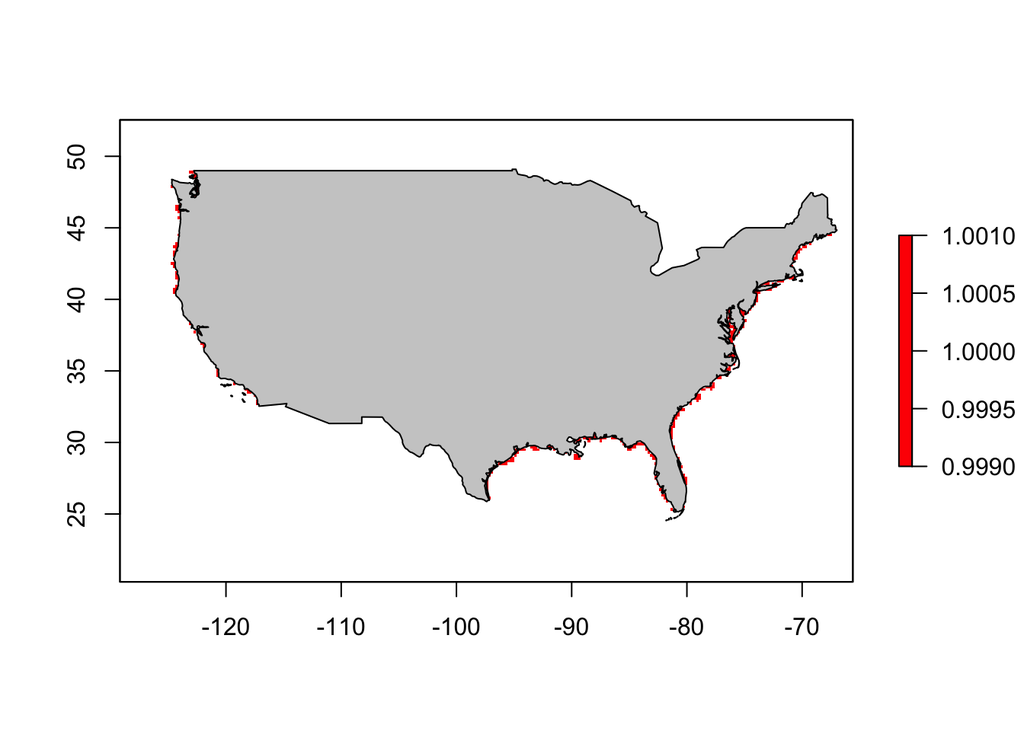

```r
# For nutrient pollution:
# Reclassify so zero values are NA
nut_reclass <- reclassify(nut_resample_mask, cbind(-Inf,0, NA))

# This is very strange. Reclassify doesn't seem to have removed all the zero values...
# freq(nut_resample_mask, value = 0)
# freq(nut_reclass, value = 0)

# Then, we can take the top 25%...
nut_quantiles <- quantile(nut_reclass)
nut_reclass_list <- c(-Inf, nut_quantiles[4], NA, nut_quantiles[4], Inf, 1)
nut_reclass_matrix <- matrix(nut_reclass_list,
                             byrow = TRUE,
                             ncol = 3)

# Reclassify so the top 25 are ones...
nut_top_25 <- reclassify(nut_reclass, nut_reclass_matrix)


plot(nut_top_25, col= "red")
plot(us_base, col = "grey80", add = TRUE)
```

#### Resample nutrient layers

For nitrate and phosphate, we want low natural nutrient areas. This is problematic, as there’s no way to parse anthro nutrients yet.

```r
# write a function for this:
nut_reclass <- function(object, pctl = 3){
  quantiles <- raster::quantile(object)
  reclass_list <- c(-Inf, quantiles[pctl], 1, quantiles[pctl], Inf, NA)
  reclass_matrix <- matrix(reclass_list,
                           ncol = 3,
                           byrow = TRUE)
  reclass <- reclassify(object, reclass_matrix)
}
```

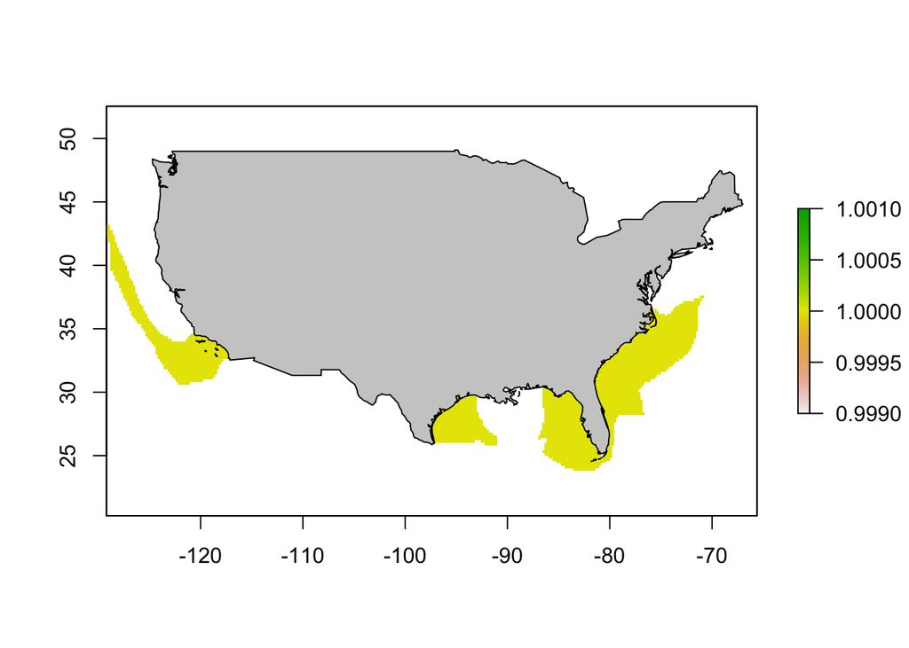

```r
# Apply it to nitrogen...
nitro_low50 <- nut_reclass(nitro_int, 3)

plot(nitro_low50)
plot(us_base, col = 'grey80', add = TRUE)
```

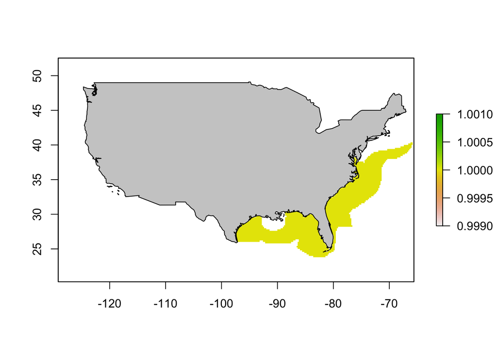

```r
# And phosphorous
phos_low_50 <- nut_reclass(phos_int, 3)

plot(phos_low_50)
plot(us_base, col = 'grey80', add = TRUE)
```

#### Resample eutrophication layer

For the eutrophication layer, whether or not there’s reported eutrophication isn’t a primary concern. I’d rather use this layer to corroborate the previous analysis:

First, I can resample the eutrophication layer so the NA’s are zero.

```r
eut_resample <- reclassify(eut_us_crop, cbind(NA, 0))
```

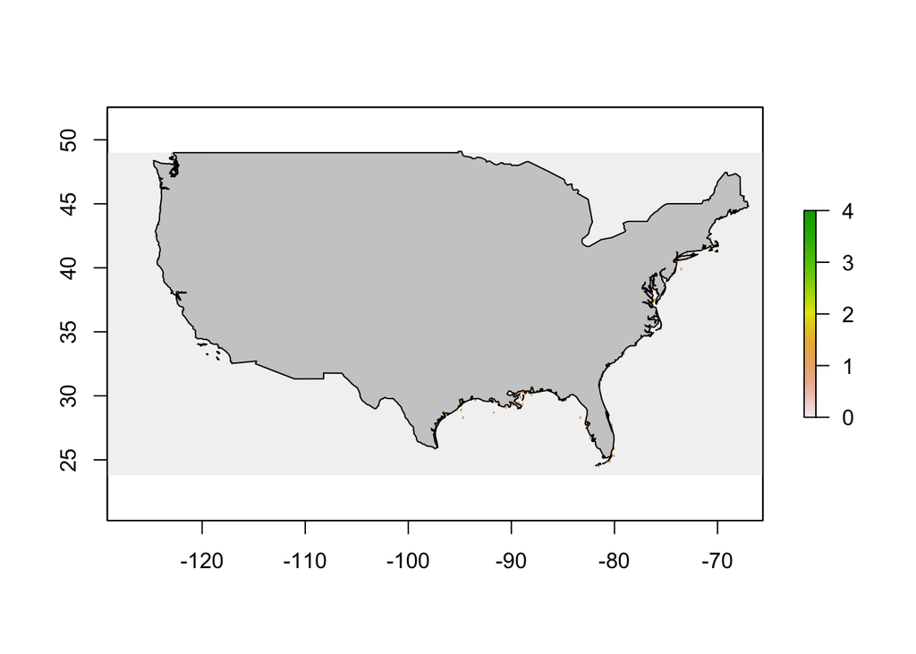

```r
# Plot the observed eutrophication locations:

plot(eut_resample)
plot(us_base, col = 'grey80', add = TRUE)
```

This is a suitability raster that incorporates all of these.

I’m using this color ramp because any value above 1 means the cell contains a point recognized as either eutrophic or hypoxic by the WOI. For this, I don’t feel the need to point out if there are multiple eutrophic points in a cell.

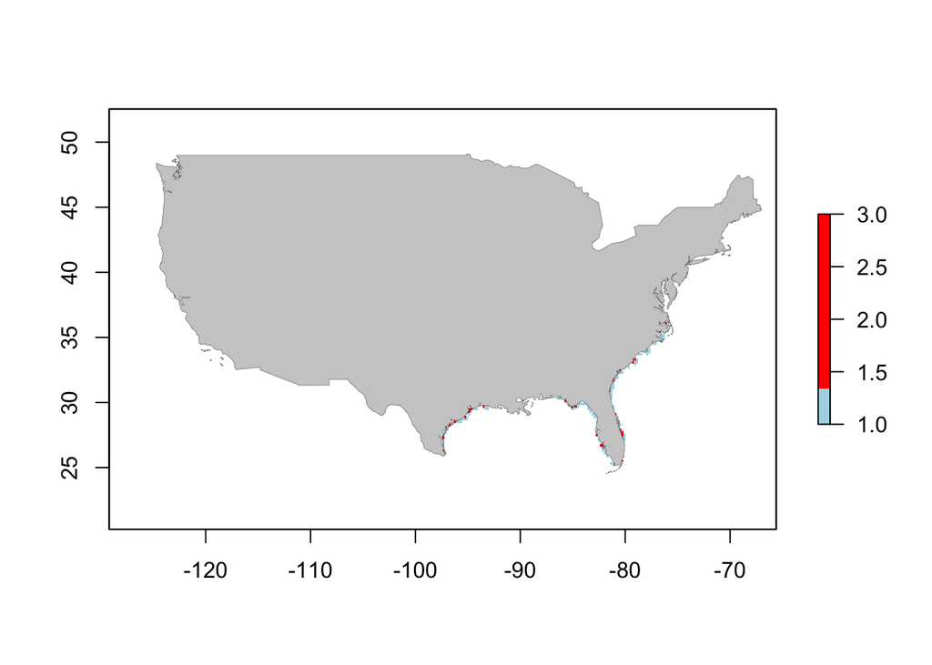

```r
suitability_raster <- ((nitro_low50 * phos_low_50 * nut_top_25) + eut_resample)

plot(suitability_raster, col = ramp)
plot(us_base, col = 'grey80', add = TRUE, lwd = 0.2)
```

This comes up with quite a few regions, particularly in the Gulf. This might be a great area for kelp suitability.

## What about high polluted areas?

What happens if I use the top 50 percent of nutrient data?

```r
  # This function gets quantiles from the input raster, then reclassifys where the HIGH values are 1 and low values are 0.

nut_reclass_upper <- function(object, pctl = 3){
  quantiles <- raster::quantile(object)
  reclass_list <- c(-Inf, quantiles[pctl], NA, quantiles[pctl], Inf, 1)
  reclass_matrix <- matrix(reclass_list,
                           ncol = 3,
                           byrow = TRUE)
  reclass <- reclassify(object, reclass_matrix)
}

nut_reclass_upper_nit <- nut_reclass_upper(nitro_int, 3)
nut_reclass_upper_phos <- nut_reclass_upper(phos_int, 3)
```

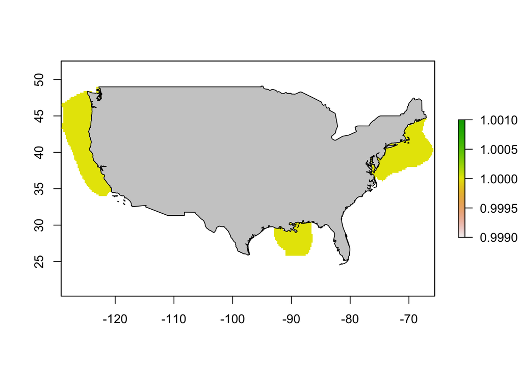

```r
plot(nut_reclass_upper_nit)
plot(us_base, col = 'grey80', add = TRUE)
```

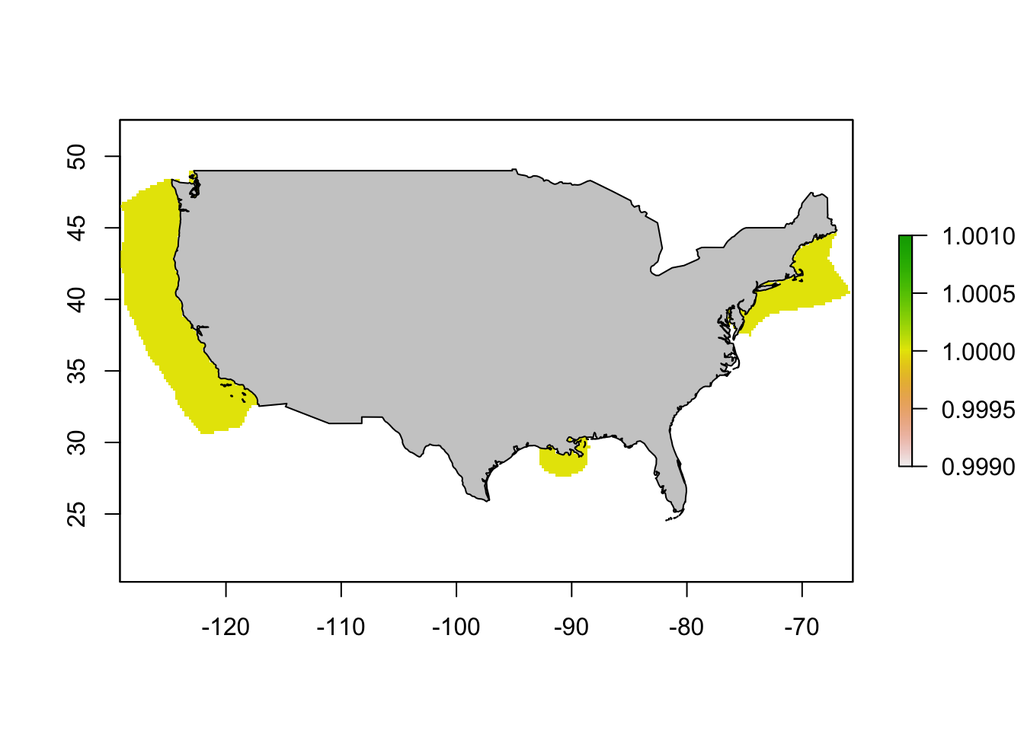

```r
plot(nut_reclass_upper_phos)
plot(us_base, col = 'grey80', add = TRUE)
```

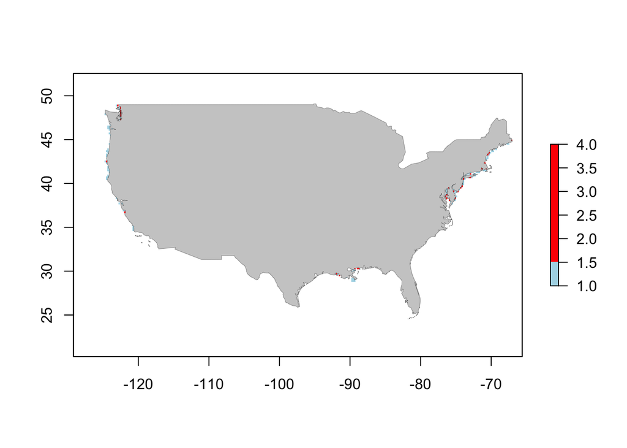

```r
high_nut_suitability_raster <- ((nut_reclass_upper_nit * nut_reclass_upper_phos * nut_top_25) + eut_resample)

plot(high_nut_suitability_raster, col = ramp)
plot(us_base, col = 'grey80', add = TRUE, lwd = 0.2)
```

```r
# This function counts the cells that are suitable in a given raster:
active_cells <- function(raster){
  a <- freq(raster, value = 1)
  b <- freq(raster, value = 2)
  c <- freq(raster, value = 3)
  d <- freq(raster, value = 4)
  e <- a + b + c + d
  return(e)
}

active_cells(high_nut_suitability_raster)
```

```
## [1] 135
```

```r
active_cells(suitability_raster)
```

```
## [1] 134
```

In this analysis, there are pretty much an equal number of suitable cells between the two.

### Bio Oracle nutrient data

I’m going to repeat the analysis from above with this new data, see what changes.

```r
# This function returns the bottom 50% of the nutrient raster
BO_nit_low <- nut_reclass(bo_nit)
BO_phos_low <- nut_reclass(bo_phos)
```